# Marsh_dataviz_Mini_Project_1_Late

#### Month and Weekday Heatmap

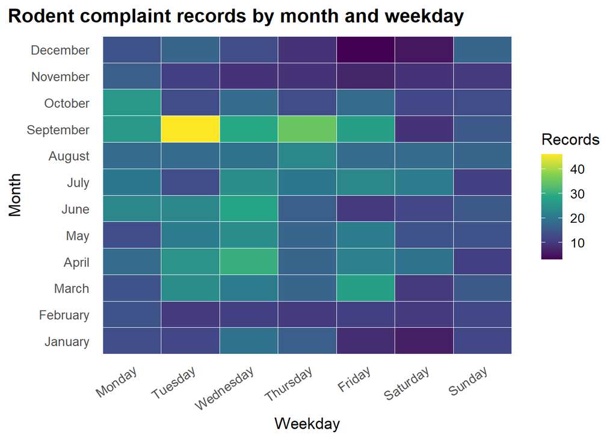

```r
month_weekday <- rats_clean %>%
  filter(!is.na(sighting_month), !is.na(sighting_weekday)) %>%
  count(sighting_month, sighting_weekday)

ggplot(month_weekday, aes(x = sighting_weekday, y = sighting_month, fill = n)) +
  geom_tile(color = "white", linewidth = 0.3) +
  scale_fill_viridis_c(labels = comma) +
  labs(
    title = "Rodent complaint records by month and weekday",
    x = "Weekday",
    y = "Month",
    fill = "Records"
  ) +
  eda_theme +
  theme(
    axis.text.x = element_text(angle = 35, hjust = 1),
    panel.grid = element_blank()
  )
```

#### Interactive Density Heatmap on NYC Map

Do zoom in for this part, i could not get the zoom right.

```r
rats_coordinates <- rats_clean %>%
  filter(!is.na(latitude), !is.na(longitude))

leaflet(rats_coordinates) %>%
  addProviderTiles(providers$CartoDB.Positron) %>%
  setView(lng = -73.95, lat = 40.72, zoom = 11) %>%
  addHeatmap(
    lng = ~longitude,
    lat = ~latitude,
    blur = 20,
    radius = 15,
    max = 0.05
  )
```

[interactive chart not shown]

### Part C: How did you apply the principles of data visualizations and design for this assignment?

I also kept the titles and labels direct, used a consistent theme, and tried to build context like a storyboard to give the reader a greater sense of context than a single graph or reading. More so following the “show, don’t tell” line of thought for this one.

#### AI USE Statement:

I used AI only to improve sentence structure and correct grammatical errors. The analysis, code, interpretations, and conclusions are my own work.